# ReproducibleResearchProject1

Lazar Kirven

September 28, 2016

## R Markdown for Reproducible Research Project 1

```r
library(dplyr)
library(ggplot2)
library(lubridate)

setwd("/Users/lazar/Code/R/ReproducibleResearch-project1/RepData_PeerAssessment1")
targetFile <- unz(description="activity.zip", filename="activity.csv")
rawData <- read.csv(targetFile, header = TRUE)
table1 <- tbl_df(rawData)
table2 <- tbl_df(rawData)
table1[is.na(table1)] <- 0

# Question 1
grouped_t1 <- group_by(table1, date)
summary1 <- summarize(grouped_t1, numsteps=sum(steps))
mymean1 <- mean(summary1$numsteps)
mymedian1 <- median(summary1$numsteps)
# Question 2
grouped_t2 <- group_by(table1, interval)
summary2 <- summarize(grouped_t2, averagesteps=mean(steps))
activeInterval <- filter(summary2, averagesteps == max(averagesteps))$interval
# Question 3
missing <- table2 %>% filter(is.na(steps))
numMissingRows <- nrow(missing)
replacementStrategy <- mutate(summary2, projectedsteps = round(averagesteps, digits = 0))
table2 <- mutate(table2, projsteps = ifelse(is.na(steps), (ifelse(interval==replacementStrategy$interval, replacementStrategy$projectedsteps, 0)), steps))
table2 <- select(table2, projsteps, date, interval)
table2 <- rename(table2, steps = projsteps)
grouped_t3 <- group_by(table2, date)
summary3 <- summarize(grouped_t3, numsteps=sum(steps))
mymean3 <- mean(summary3$numsteps)
mymedian3 <- median(summary3$numsteps)
# Question 4
table4 <- mutate(table2, weekInd = ifelse(wday(date)==1|wday(date)==7, "weekend", "weekday"))
```

**What is mean total number of steps taken per day?**

*(1) Dataset listing the total number of steps taken per day*

```r
summary1
```

```
## # A tibble: 61 x 2
##          date numsteps
##        <fctr>    <dbl>
## 1  2012-10-01        0
## 2  2012-10-02      126
## 3  2012-10-03    11352
## 4  2012-10-04    12116
## 5  2012-10-05    13294
## 6  2012-10-06    15420
## 7  2012-10-07    11015
## 8  2012-10-08        0
## 9  2012-10-09    12811
## 10 2012-10-10     9900
## # ... with 51 more rows
```

*(2) Histogram*

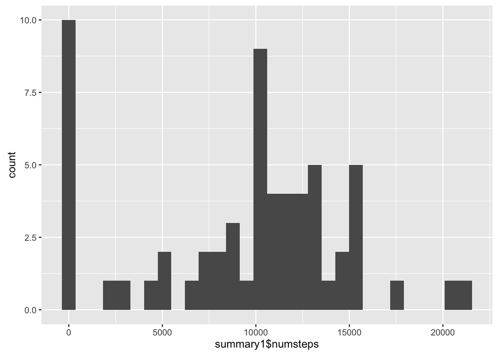

```r
qplot(summary1$numsteps, geom="histogram")
```

*(3) Calculate and report the mean and median*  
Mean of the total number of steps taken per day is 9354.23  
Median of the total number of steps taken per day is 10395

**What is the average daily activity pattern?**

*(1) Time series plot*

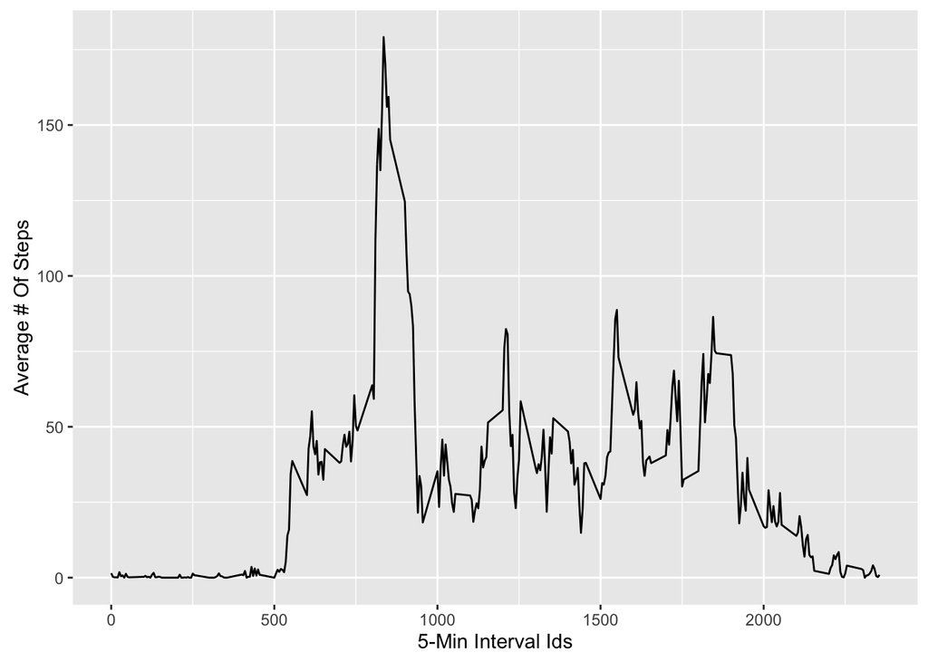

```r
qplot(x=interval, y=averagesteps, data=summary2, geom = "line", xlab = "5-Min Interval Ids", ylab = "Average # Of Steps")
```

*(2) Most active interval on average is:* 835

**Inputing missing values**

*(1) Total number of missing values:* 2304

*(2) Replacement strategy is to replace ‘NA’ values with an average number number of steps for that particular 5-minute interval*

```r
replacementStrategy
```

```
## # A tibble: 288 x 3
##    interval averagesteps projectedsteps
##       <int>        <dbl>          <dbl>
## 1         0   1.49180328              1
## 2         5   0.29508197              0
## 3        10   0.11475410              0
## 4        15   0.13114754              0
## 5        20   0.06557377              0
## 6        25   1.81967213              2
## 7        30   0.45901639              0
## 8        35   0.75409836              1
## 9        40   0.00000000              0
## 10       45   1.27868852              1
## # ... with 278 more rows
```

*(3) New dataset with replacement strategy*

```r
table2
```

```
## # A tibble: 17,568 x 3
##    steps       date interval
##    <dbl>     <fctr>    <int>
## 1      1 2012-10-01        0
## 2      0 2012-10-01        5
## 3      0 2012-10-01       10
## 4      0 2012-10-01       15
## 5      0 2012-10-01       20
## 6      2 2012-10-01       25
## 7      0 2012-10-01       30
## 8      1 2012-10-01       35
## 9      0 2012-10-01       40
## 10     1 2012-10-01       45
## # ... with 17,558 more rows
```

*(4) Histogram*

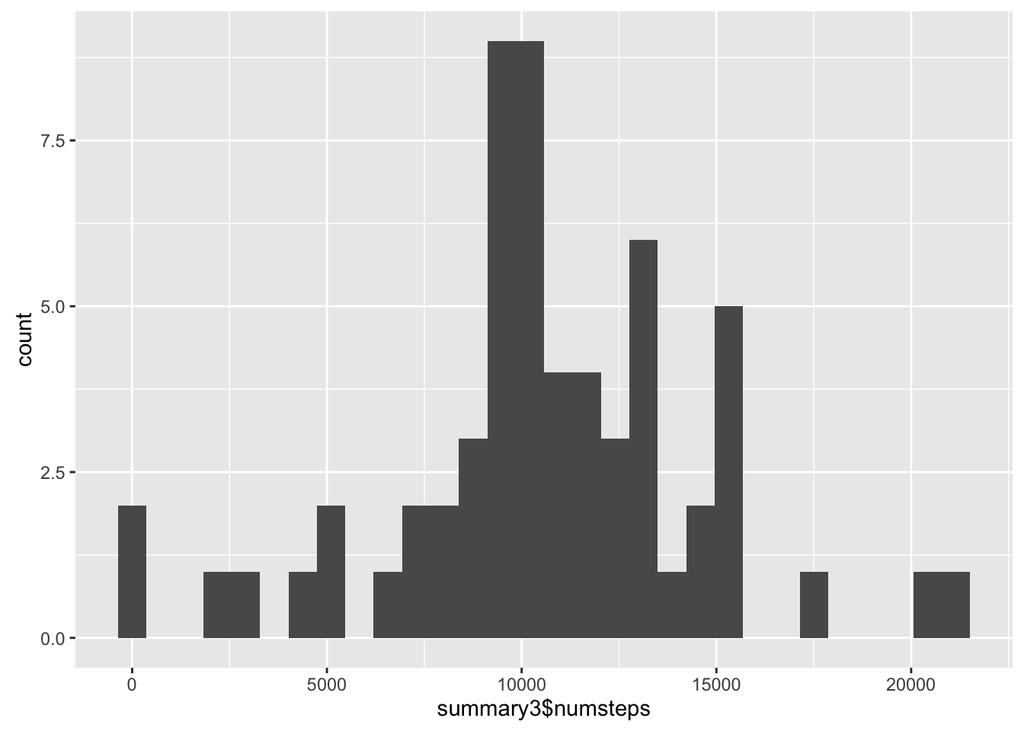

```r
qplot(summary3$numsteps, geom="histogram")
```

Mean of the total number of steps taken per day is 10580.72  
Median of the total number of steps taken per day is 10395

*(a) Do these values differ from the estimates from the first part of the assignment? What is the impact of imputing missing data on the estimates of the total daily number of steps?*

The median values are the same, but the mean are different. First part of the assigment has a lower mean value. The impact is the mean value is higher since I replaced the ‘NA’ values with an average steps for that 5-minute interval.

**Are there differences in activity patterns between weekdays and weekends?**

*(1) New dataset with new week indicator factor*

```r
table4
```

```
## # A tibble: 17,568 x 4
##    steps       date interval weekInd
##    <dbl>     <fctr>    <int>   <chr>
## 1      1 2012-10-01        0 weekday
## 2      0 2012-10-01        5 weekday
## 3      0 2012-10-01       10 weekday
## 4      0 2012-10-01       15 weekday
## 5      0 2012-10-01       20 weekday
## 6      2 2012-10-01       25 weekday
## 7      0 2012-10-01       30 weekday
## 8      1 2012-10-01       35 weekday
## 9      0 2012-10-01       40 weekday
## 10     1 2012-10-01       45 weekday
## # ... with 17,558 more rows
```

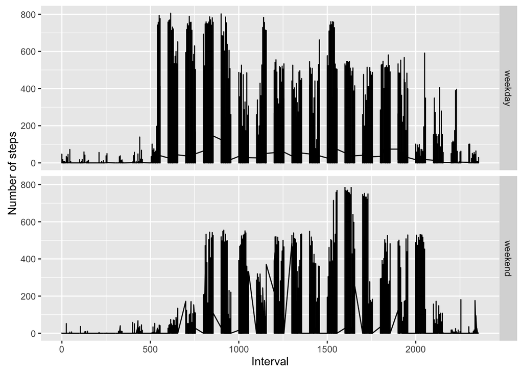

```r
ggplot(table4, aes(x = interval, y = steps, group = weekInd)) + geom_line() +
    facet_grid(weekInd~.) +
    xlab("Interval") +
    ylab("Number of steps")
```